# Code Testing

Ian Roberts

09/06/2021

## Structured Simulation Testing

Generate datasets of size $n$ observations with

- Random sample times uniform between two years (default 2010 to 2021)
- Random demes sampled uniformly at random from 1:n.deme (default n.deme = 2)

```r
Test.data <- function(n, n.deme = 2, lower.year = 2010, upper.year = 2021){
  data <- matrix(0,nrow = n, ncol = 3)
  data[,1] <- 1:n
  data[,2] <- runif(n, min = lower.year, max = upper.year + 1)
  data[,3] <- sample.int(n.deme, n, replace = TRUE)
  data
}
```

Run $N$ repetitions computing the recursive likelihood under Structured.sim and the likelihood from structured.likelihood with unique test datasets.

```r
N <- 100  #Number of repetitions
n <- 100  #Sample size
n.deme <- 2
migration.mat <- matrix(runif(n.deme^2, 0, 0.1),n.deme, n.deme)

likelihoods <- matrix(0,nrow = N,ncol = 2)

for (i in 1:N){
  phylo <- Structured.sim(Test.data(n,n.deme), 1,1,n.deme,migration.mat,FALSE)
  likelihoods[i,1] <- phylo$log.likelihood
  likelihoods[i,2] <- structured.likelihood(phylo,1,1,migration.mat)[1]
}

max(abs(likelihoods[,1] - likelihoods[,2]))
```

```
## [1] 2.557954e-13
```

Consistently returns discrepancies between calculated likelihoods of order $10^{-13}$ suggesting accurate computations are being made.

*Initially a discrepancy arose from removing the diagonal of migration.mat in Structured.sim but not in structured.likelihood*

Repeating the testing with a greater number of demes:

```r
N <- 100
n.deme <- 5

migration.mat <- matrix(runif(n.deme^2),n.deme, n.deme)

likelihoods <- matrix(0,nrow = N,ncol = 2)

for (i in 1:N){
  phylo <- Structured.sim(Test.data(n,n.deme), 1,1,n.deme,migration.mat,FALSE)
  likelihoods[i,1] <- phylo$log.likelihood
  likelihoods[i,2] <- structured.likelihood(phylo,1,1,migration.mat)[1]
}

max(abs(likelihoods[,1] - likelihoods[,2]))
```

```
## [1] 1.932676e-12
```

confirm that the likelihoods computed under structured.sim agree with the heterochronous coalescent without migration when there is a single deme.

```r
n.deme <- 1
N <- 100

migration.mat <- matrix(1,1,1)

likelihoods <- matrix(0,N,3)

for (i in 1:N){
  phylo <- Structured.sim(Test.data(n,n.deme), 1,1,n.deme,migration.mat,FALSE)
  likelihoods[i,1] <- phylo$log.likelihood
  likelihoods[i,2] <- structured.likelihood(phylo,1,1,migration.mat)[1]
  likelihoods[i,3] <- phylo.likelihood(phylo,1,1)[1]
}

max(abs(likelihoods[,1] - likelihoods[,2]))
```

```
## [1] 1.847411e-13
```

```r
max(abs(likelihoods[,2] - likelihoods[,3]))
```

```
## [1] 0
```

Consistently, the likelihoods calculated for the structured coalescent with a single deme (using structured.likelihood) correspond exactly to the heterochronous coalescent (using phylo.likelihood)

## MCMC Implementation Testing

Begin by testing a MCMC algorithm with a single type of move (migration birth/death).

TESTING MIGRATION BIRTH/DEATH MOVE ONLY

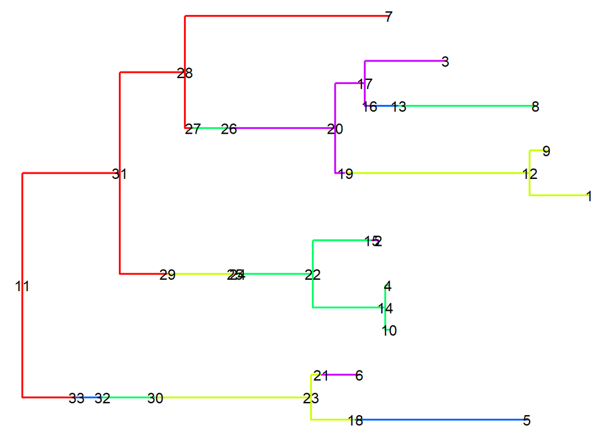

```r
n <- 10
n.deme <- 5
migration.mat <- matrix(runif(n.deme^2, 0, 0.1),n.deme, n.deme)
phylo <- Structured.sim(Test.data(n,n.deme), 1,1,n.deme,migration.mat,FALSE)
structured.plot(phylo); nodelabels(frame = "none"); tiplabels(frame = "none")
```

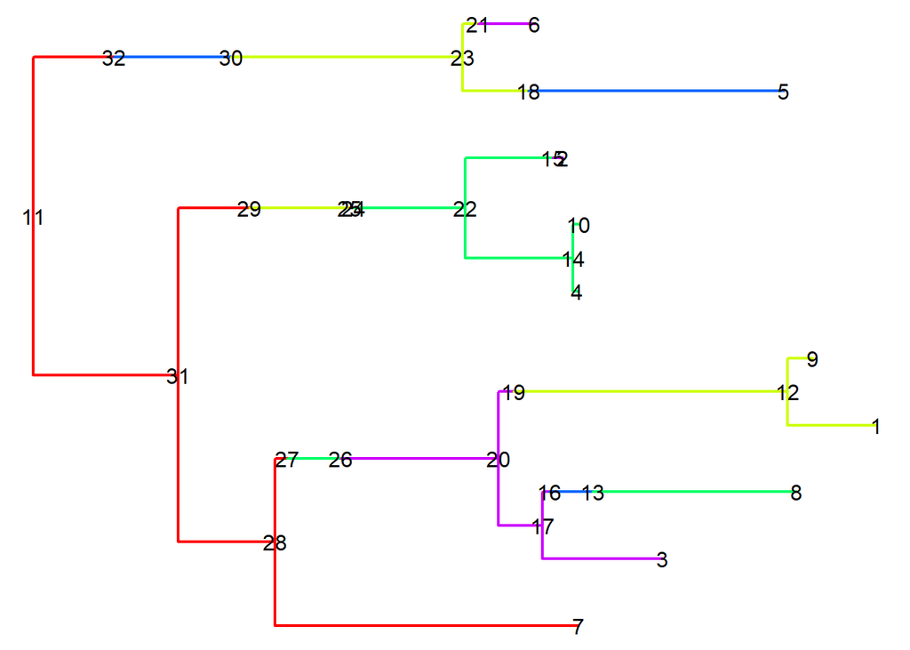

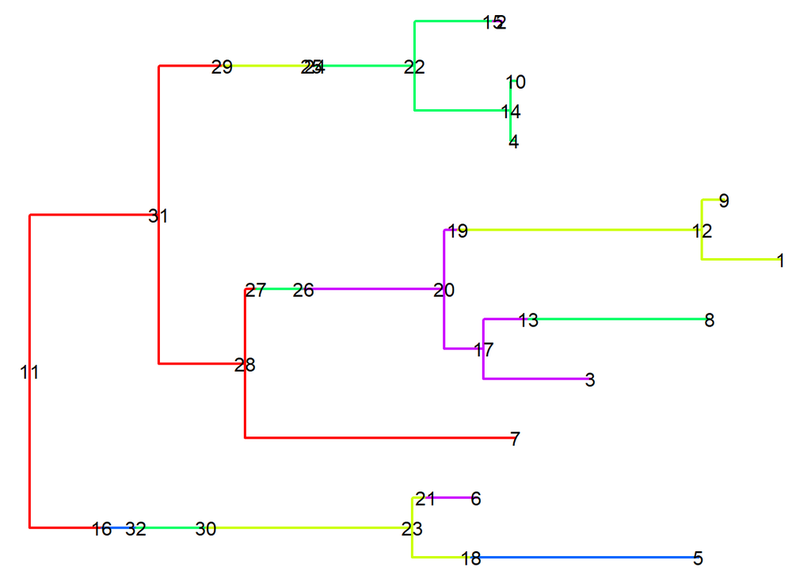

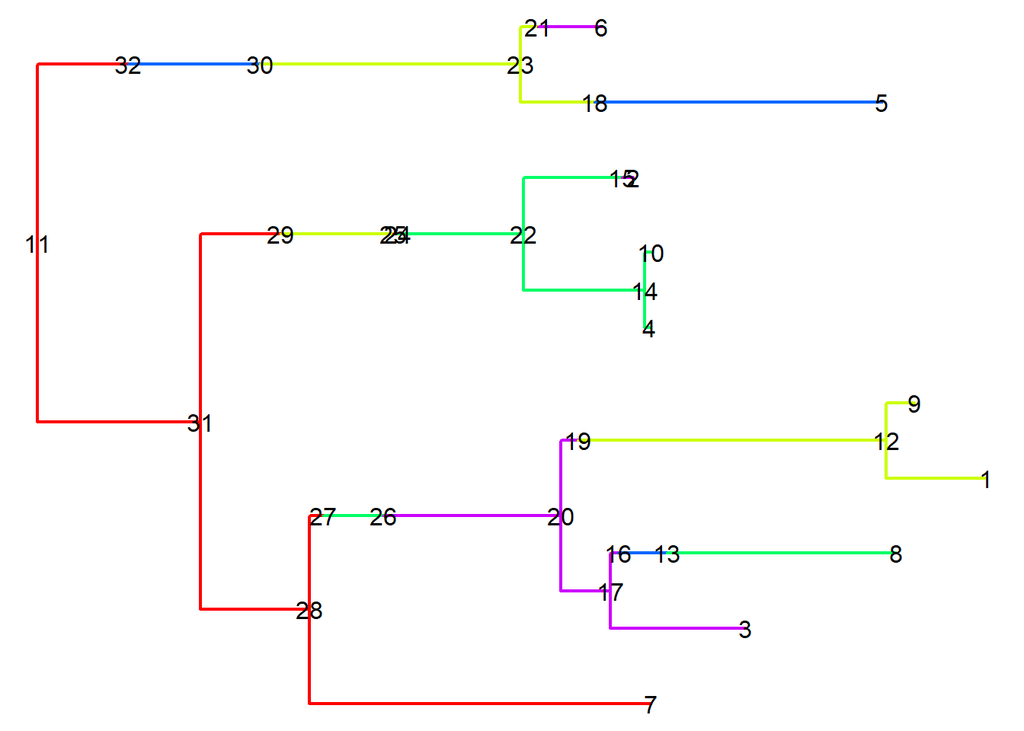

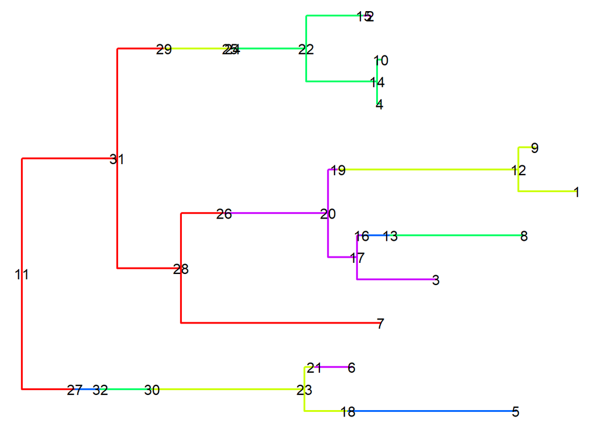

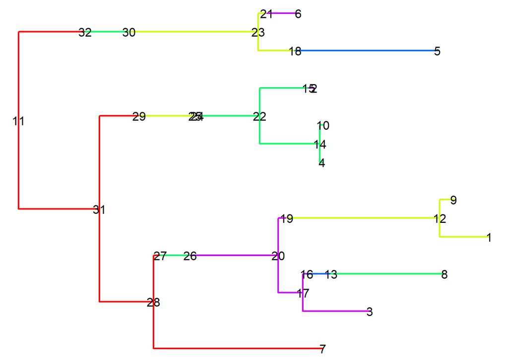

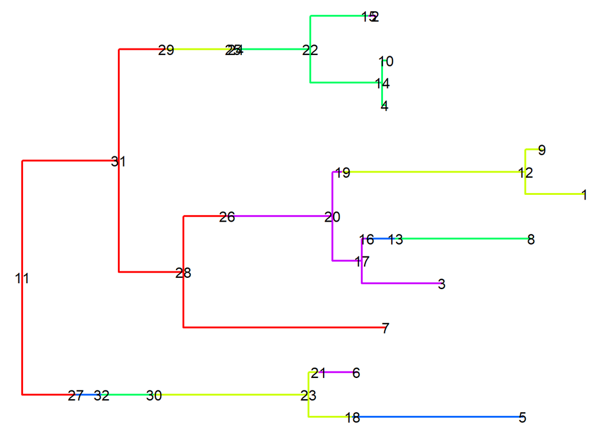

```r
ED <- phylo.to.ed(phylo)

for (i in 1 : 10){
  Out <- ed.mig.death.new(ED, n.deme); Out$prop.ratio
  if (Out$prop.ratio > 0){
    new.phylo <- ed.to.phylo(Out$ED)
    structured.plot(new.phylo); nodelabels(frame = "none"); tiplabels(frame = "none")
  }
}
```

Burn in phase 100 iterations, main run 1000 iterations; prior ratio 1 and likelihood ratio given by ratio of poisson(1) distributions on number of migration events. Select migration birth w/prob p and migration death w/prob 1-p

```r
set.seed(1)
N0 <-  10^2 #Burn in phase
N <- 10^3
p <- 1/2
sample <- numeric(N)

n <- 100
n.deme <- 3
migration.mat <- matrix(runif(n.deme^2, 0, 1),n.deme, n.deme)
phylo <- Structured.sim(Test.data(n,n.deme), 1,1,n.deme,migration.mat,FALSE)  #Initial tree
ED <- phylo.to.ed(phylo)

for (i in 1:(N0 + N)){
  U <- runif(1)

  if (U <= p){ #Birth
    proposal <- ed.mig.birth.3(ED, n.deme, FALSE) #ed.mig.birth.new(ED, n.deme)
  } else{ #Death
    proposal <- ed.mig.death.3(ED, n.deme, FALSE) #ed.mig.death.new(ED, n.deme)
  }

  ED.n.mig <- length(ED[is.na(ED[,4]) & (! is.na(ED[,3])), 1])  #Number of migrations in current tree
  prop.ED <- proposal$ED
  prop.n.mig <- length(prop.ED[is.na(prop.ED[,4]) & (! is.na(prop.ED[,3])), 1])  #Number of migrations in proposal

  accept.prob <- min(1, factorial(ED.n.mig)/factorial(prop.n.mig) * proposal$prop.ratio)

  V <- runif(1)

  if (V <= accept.prob){
    ED <- proposal$ED
  }

  if (i > N0){
      sample[i-N0] <- length(ED[is.na(ED[,4]) & (! is.na(ED[,3])), 1])
  }
}
summary(as.factor(sample))
```

```
##       0       1       2      55       3      11      68      29      70      37
##     186     151      77      31      30      21      17      16      14      13
##      20      30      78     108      10      18      58      28      39      16
##      12      12      12      12      11      11      11      10      10       9
##      31      35      38      34      43      98     102      15     101       5
##       9       9       9       8       8       8       8       7       7       6
##       6      12      24      26      99     121       8      13      25      40
##       6       6       6       6       6       6       5       5       5       5
##      61      63      66       7       9      22      44      46      59      62
##       5       5       5       4       4       4       4       4       4       4
##      71      76      79      82     111     113     114     116     117     120
##       4       4       4       4       4       4       4       4       4       4
##      17      27      33      47      51      52      67      69      81      91
##       3       3       3       3       3       3       3       3       3       3
##      92      93      96     104     109     110       4      21      32      41
##       3       3       3       3       3       3       2       2       2       2
##      45      48      49      50      53      56      64      65      77      83
##       2       2       2       2       2       2       2       2       2       2
##      85      88      89      90      94      97     100     103      14 (Other)
##       2       2       2       2       2       2       2       2       1      23
```

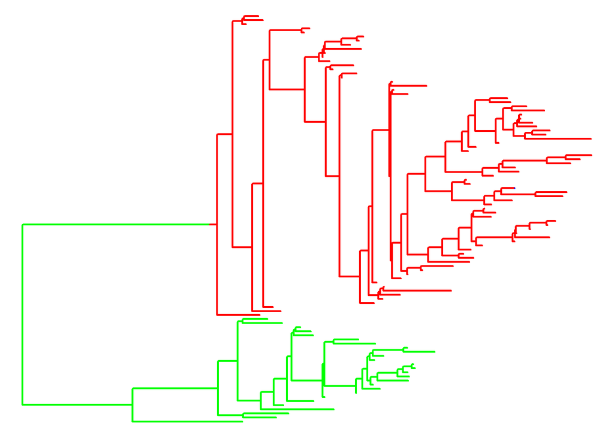

```r
structured.plot(ed.to.phylo(ED)) #;nodelabels(frame = "none")
```

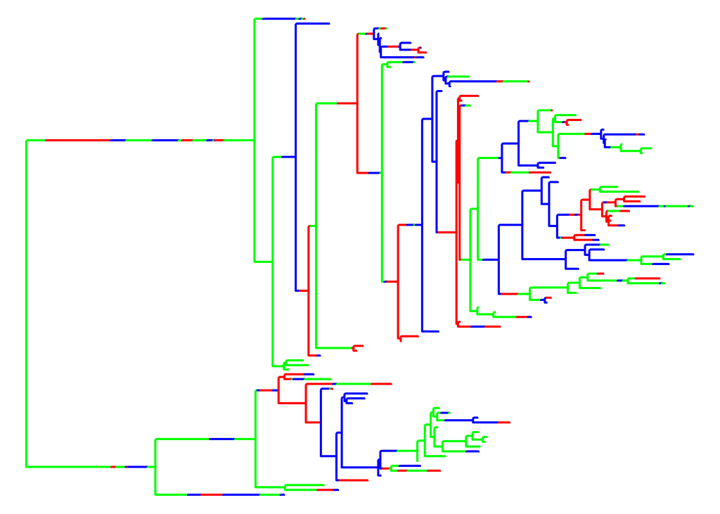

```r
structured.plot(phylo) #;nodelabels(frame = "none")
```

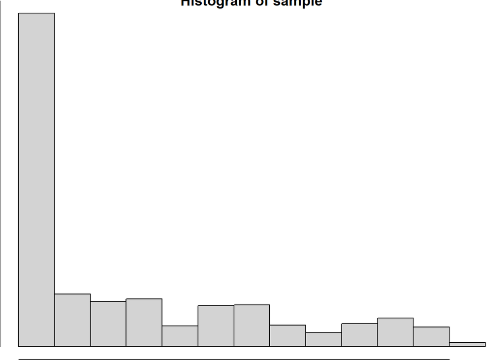

```r
hist(sample)
```

Construct a tree with $n$ homochronous leaves such that all lineages migrate into deme 1 almost immediately after the sample is drawn and no more migrations occur. Assume also that all generated data do not begin in deme 1.

Initialising at this tree reduces the possiblity of having to reject any proposal due to a leaf being included in the subtree and also starts at an almost minimal number of migration events.

```r
n <- 20
n.deme <- 3
DATA <- matrix(c(1:n, rep(0,n), sample(2:n.deme, n, replace = TRUE)), n)

migration.matrix <- matrix(0.3, n.deme,n.deme)
diag(migration.matrix) <- 0

tree.top <- Homochronous.Sim(1:n, 1, 1)
tree.top$node.deme <- rep(1, 2*n-1)
fake.ED <- phylo.to.ed(tree.top)

max.node <- max(fake.ED[,1])
node.labels <- fake.ED[,1:4]

for (i in 1:n){
  node.labels[which(node.labels == i)] <- max.node + i
}

fake.ED[,1:4] <- node.labels

for (i in 1:n){
  fake.ED <- rbind(fake.ED, c(i, max.node + i, NA, NA, sample((1:n.deme)[-fake.ED[i, 5]], 1), fake.ED[i, 6] + 1e-3))
  fake.ED[i, 3] <- i
}

structured.plot(ed.to.phylo(fake.ED))
```

Run the MCMC with Poisson likelihood for this artificial tree. The minimum number of migration events possible in this tree is 20 as none of the current migration nodes may be removed. (Should obtain a 20 + Poi(1) sample???)

```r
N <- 1e3
p <- 0.5
sample <- numeric(N)

ED <- fake.ED
for (i in 1:N){
  if (i/2 != floor(i/2)){ #Birth
    proposal <- ed.mig.birth.3(ED, n.deme) #ed.mig.birth.new(ED, n.deme)
  } else{ #Death
    proposal <- ed.mig.death.3(ED, n.deme) #ed.mig.death.new(ED, n.deme)
  }

  ED.n.mig <- length(ED[is.na(ED[,4]) & (! is.na(ED[,3])), 1])  #Number of migrations in current tree
  prop.ED <- proposal$ED
  prop.n.mig <- length(prop.ED[is.na(prop.ED[,4]) & (! is.na(prop.ED[,3])), 1])  #Number of migrations in proposal

  accept.prob <- min(1, factorial(ED.n.mig)/factorial(prop.n.mig) * proposal$prop.ratio)

  V <- runif(1)

  if (V <= accept.prob){
    ED <- proposal$ED
  }

  sample[i] <- length(ED[is.na(ED[,4]) & (! is.na(ED[,3])), 1])
}
structured.plot(ed.to.phylo(fake.ED))
structured.plot(ed.to.phylo(ED))
```

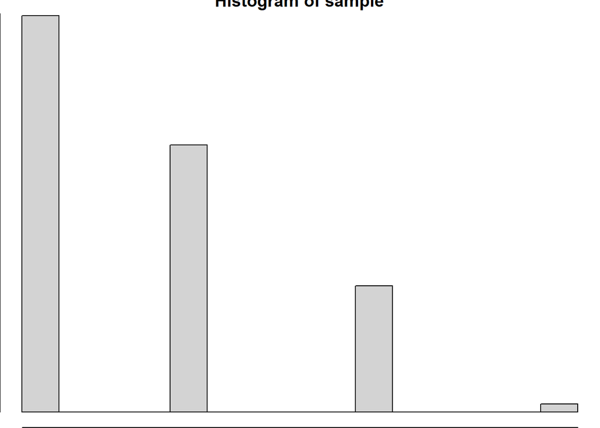

```r
hist(sample)
```

```r
structured.plot(ed.to.phylo(proposal$ED))
```

## Testing MCMC with a single-colour input

Generate a structured coalescent genealogy with no migration events and run the MCMC algorithm with Poisson likelihoods. Still permit migration events to be added, but also permit leaf demes to be changed as necessary.

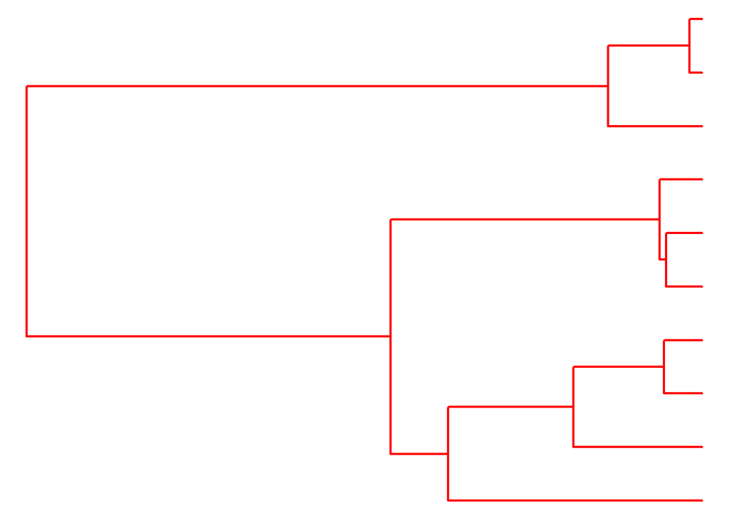

```r
#set.seed(10)
N <- 1e5  #Number of MCMC iterations

n <- 10  #Number of leaves in the tree
n.deme <- 5
phylo <- Homochronous.Sim(1:n, 1, 1)
phylo$node.deme <- rep(1, 2*n - 1)

ED <- phylo.to.ed(phylo)
structured.plot(phylo)
```

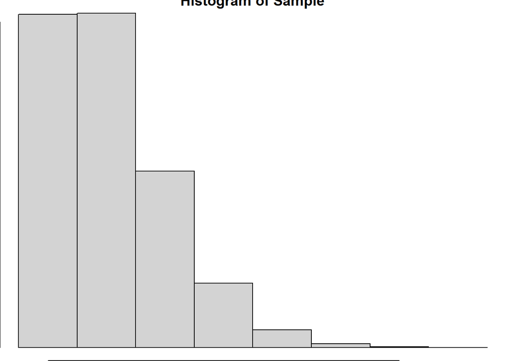

```r
migration.mat <- matrix(0.3, n.deme, n.deme)
diag(migration.mat) <- 0

Sample <- numeric(N)

for (i in 1:N){
  #if (i >= 118){ browser()}

  U <- runif(1)

  if (U <= 0.5){
    proposal <- ed.mig.birth.3(ED, n.deme, FALSE)
  } else {
    proposal <- ed.mig.death.3(ED, n.deme, FALSE)
  }

  ED.n.mig <- length(ED[ is.na(ED[,4]) & (!is.na(ED[,3])) ,1])
  prop.n.mig <- length(proposal$ED[ is.na(proposal$ED[,4]) & (!is.na(proposal$ED[,3])), 1])

  accept.prob <- min(1, factorial(ED.n.mig)/factorial(prop.n.mig) * proposal$prop.ratio)

  V <- runif(1)

  if (V <= accept.prob){  #ACCEPT
    ED <- proposal$ED
    #browser()
    #structured.plot(ed.to.phylo(ED))
    Sample[i] <- prop.n.mig
  } else{  #REJECT
    Sample[i] <- ED.n.mig
  }
}

hist(Sample, breaks = (min(Sample)-0.5):(max(Sample)+1), probability = TRUE)
```

```r
print("MCMC Sample"); summary(as.factor(Sample))
```

```
## [1] "MCMC Sample"
```

```
##     0     1     2     3     4     5     6     7
## 35801 35937 18964  6925  1883   393    89     8
```

```r
print("Poisson Sample"); summary(as.factor(rpois(N, 1)))
```

```
## [1] "Poisson Sample"
```

```
##     0     1     2     3     4     5     6     7     8
## 36632 36893 18418  6154  1535   312    47     7     2
```

## Testing MCMC algorithm with multi-colour input tree

Stick with homochronous leaves, but relax the assumption that the initial tree remains in deme 1 throughout. Generate a tree using Structured.sim with $n=10$ tips and initial demes sampled from 1:n.deme with replacement. Add also 100 burn-in iterations to avoid skewing the number of migrations by the intial tree.

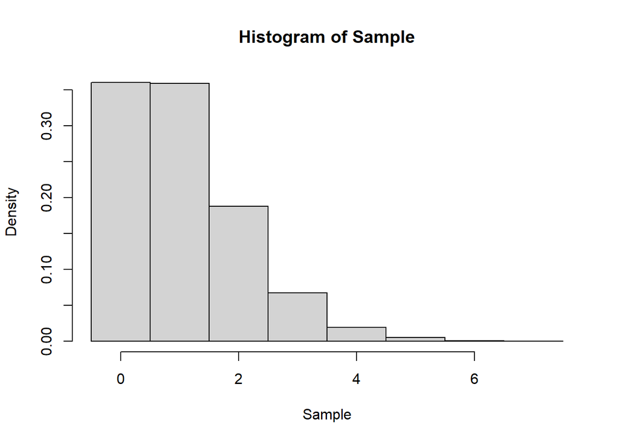

```r
N0 <- 1e2  #Number of burn-in iterations
N <- 1e5  #Number of MCMC iterations

n <- 10  #Number of leaves in the tree
n.deme <- 5

Data <- matrix(c(1:n, rep(0, n), sample.vector(1:n.deme, n, TRUE)), n, 3)
migration.mat <- matrix(0.3, n.deme, n.deme)
diag(migration.mat) <- 0

phylo <- Structured.sim(Data, 1, 1, n.deme, migration.mat)

ED <- phylo.to.ed(phylo)

Sample <- numeric(N)

for (i in (-N0):N){
  #if (i >= 118){ browser()}

  U <- runif(1)

  if (U <= 0.5){
    proposal <- ed.mig.birth.3(ED, n.deme, FALSE)
  } else {
    proposal <- ed.mig.death.3(ED, n.deme, FALSE)
  }

  ED.n.mig <- length(ED[ is.na(ED[,4]) & (!is.na(ED[,3])) ,1])
  prop.n.mig <- length(proposal$ED[ is.na(proposal$ED[,4]) & (!is.na(proposal$ED[,3])), 1])

  accept.prob <- min(1, factorial(ED.n.mig)/factorial(prop.n.mig) * proposal$prop.ratio)

  V <- runif(1)

  if (V <= accept.prob){  #ACCEPT
    ED <- proposal$ED
    #browser()
    #structured.plot(ed.to.phylo(ED))
    if (i > 0){
      Sample[i] <- prop.n.mig
    }
  } else{  #REJECT
    if (i > 0){
      Sample[i] <- ED.n.mig
    }
  }
}

hist(Sample, breaks = (min(Sample)-0.5):(max(Sample)+1), probability = TRUE)
```

```r
print("MCMC Sample"); summary(as.factor(Sample))
```

```
## [1] "MCMC Sample"
```

```
##     0     1     2     3     4     5     6     7
## 35978 35898 18799  6748  1954   523    93     7
```

```r
print("Poisson Sample"); summary(as.factor(rpois(N, 1)))
```

```
## [1] "Poisson Sample"
```

```
##     0     1     2     3     4     5     6     7     8
## 36772 36781 18446  6079  1602   273    44     2     1
```